# Scater Plot Analysis

## Methodology

This analysis examines the relationship between Process Index (normalized prolongamento) and Complexity Index (normalized Index_complex) across different experimental conditions. Data normalization was performed by scaling values relative to the control group mean, setting the control baseline to 50.

Statistical analyses include:

- **PERMANOVA** (Permutational Multivariate Analysis of Variance): Tests for significant differences in multivariate dispersion between groups using Euclidean distances with 1,000 permutations
- **PERMDISP** (Permutational Analysis of Multivariate Dispersions): Assesses homogeneity of multivariate dispersions across groups using pairwise permutation tests with 1,000 permutations

Visualizations display 2D density contours overlaid on scatter plots, with reference lines at the control mean (50, 50) shown as red dashed lines. All plots use log-scale for the y-axis to better visualize the data distribution.

# PERMANOVA and Dispersion Analysis

## Control-only

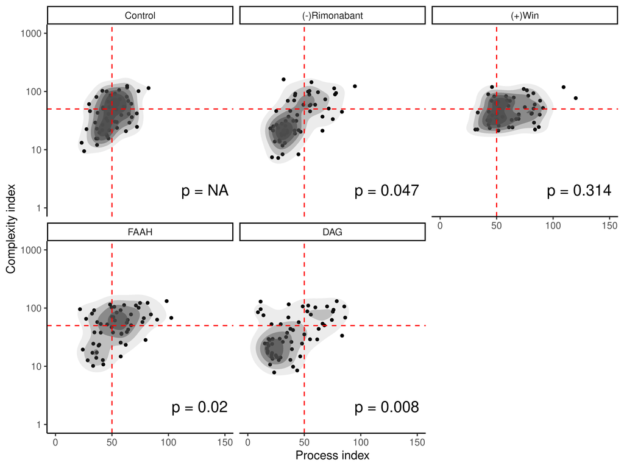

## Cortico-only

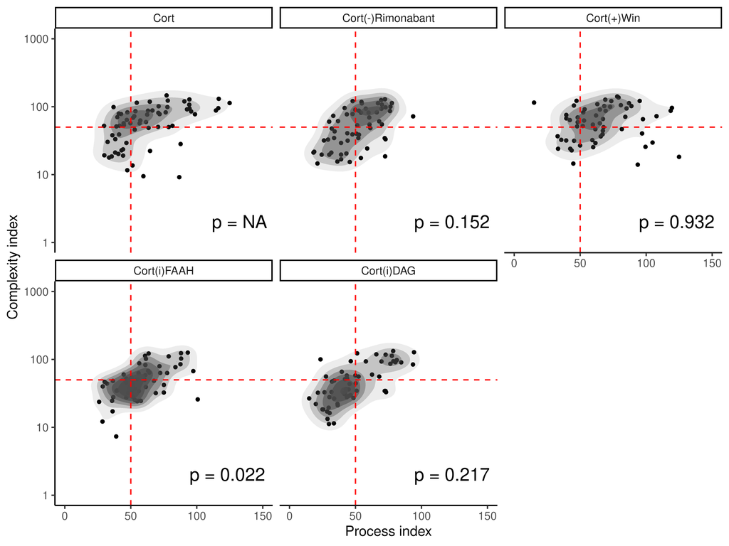

## Overall

[figure not shown]

**Figure 3:** Comprehensive comparison of all experimental conditions showing the density distribution of Process Index vs. Complexity Index. This overview displays both control-based conditions (top row) and corticosterone-treated conditions (bottom row) in a single visualization. Grey density contours illustrate the concentration of data points for each condition. Red dashed lines mark the control reference baseline at (50, 50). This figure allows for direct visual comparison of how different cannabinoid system modulations affect microglial morphology parameters, both in basal conditions and under corticosterone-induced stress. Y-axis is displayed in log-scale.